# Thirteen Ways of Looking at Malaria

Modeling Malaria Infection & Immunity

November 29, 2023

`~/Malaria Epidemiology/Modeling-Infection.Rmd`

HUB – Roadmap – Library – Malaria Epidemiology – Theory

This vignette is focused on forging a *synthesis* of malaria models. The related vignette on theory takes more of a historical perspective, including a bibliography. Also, see Scaling (also, the ms)

**NOTE:** The title was borrowed from Wallace Steven’s great poem, *13 Ways of Looking at a Blackbird.* One stanza from that poem heads each section.

## $\odot$

### Abstract

Malaria models are routinely used in malaria research and policy, despite a great deal of uncertainty. The malaria models in use today have evolved over time to incorporate new ideas and new concepts, often when the models have been challenged with data and proven inadequate in some way [1–3]. In the following synthetic review, we start by presenting a set of basic concepts using simple models of malaria infection and immunity. Next, we use these simple models as building blocks to construct models with a greater degree of complexity and realism to match the features of malaria data. In the end, we will address four questions:

1. *How well do we understand malaria infections in humans?*
2. *Do we understand infection with malaria parasites well enough to give useful policy advice about malaria control?*
3. *What are the essential features of malaria models?*
4. *What makes a malaria model good?*

While there are many ways of being good, we care most about using models to formulate malaria policy advice, where the stakes are high. If we get it wrong, people might die. On the other hand, there’s a lot about malaria we still don’t know. How can we ensure that we’re giving good advice, given the uncertainty?

There is some hope of answering these questions well, even if we don’t know everything. The principle of parsimony would advise us to build models that are *as simple as possible, but no simpler* (the quote is attributed to Einstein). A principle of robustness suggests that simple models are useful, even if they are wrong, but how wrong can a model be before it ceases to be useful (from George Box). A very serious question for us is what are the essential features of malaria models for policy? Are there some comparatively models that are capable of dealing with the complexity and uncertainty well enough to give advice?

Malaria models have *already* been used in policy. Ross developed the models to understand malaria transmission well enough to formulate coherent ideas about control, and he used his intuition to formulate advice [4–7]. Ross’s simple model – it would now be called an SIS compartment model – was used to help set the response timelines for the Global Malaria Eradication Programme [8–10].

Towards the end of the Global Malaria Eradication Programm (1955-1969), the Ross-Macdonald model was used to help design a malaria control trial in Kankiya District, northern Nigeria (1966-1969); the model predictions differed substantially from the trial results, leading to calls for a new mathematical model [11]. In short order, a new model had been developed with malaria immunity and some other features, and it was used to design a new trial, conducted in Garki, Nigeria (1972-73) [12]. The Garki model was innovative in several ways, but two are particularly relevant: it introduced new epidemiological states representing different stages of malaria immunity; and while Macdonald had formulated a flawed model of superinfection [13,14], but the Garki model found an elegant approximation. Shortly thereafter, Dutertre published a model that represented malaria infections using a different set of epidemiological states [15]. Since then, new models have been developed to address many aspects of malaria infection and immunity. The variety of models raises a question – what are the core mechanisms driving patterns in malaria epidemiology, and how should those mechanisms be represented in dynamical models?

Given our interest in policy, the ultimate goal is to identify the features of models that are realistic enough, and with enough skills to address the needs of malaria programs. Over the past century, models for policy have focused on malaria elimination, which emphasizes the suppression of transmission. As the emphasis has shifted to reducing the burden of malaria, there is a greater need to understand disease and mortality. Models for policy must be synthetic: they must address questions about exposure, infection, treatment, malaria burden, infectiousness, and detection. We want to do this without resorting to stochastic, individual-based models. Such models play an important role in malaria, but with so much stochasticity, the models are difficult to understand, critically evaluate, and use. We would like to develop a conceptual framework and an accompanying computational framework that allows us to clearly identify what is going wrong with the models, not to bring about paralysis, but to build ensembles of models that cover the uncertainty.

In this vignette, we review mathematical models for human malaria infections through 13 core concepts. Each concept is framed as a model that addresses one dimension of the complexity of malaria. Our core interest here is to develop models that can support malaria policy. The critical question, which we come to at the end, is what areas of uncertainty about malaria matter when it comes time to formulate malaria policies.

## 1.

### $\oplus$

Among twenty snowy mountains,  
The only moving thing  
Was the eye of the blackbird.

$\frac{dX}{dt} = h (H-X)-rX$

### Background

In 1897, Ronald Ross observed malaria parasites under a light microscope, earning a place in history [16]. Shortly after that, his interests turned to malaria control. In 1899, he wrote enthusiastically about the *extermination* of malaria through mosquito control [17], and over the next decade, he devoted himself to *The Prevention of Malaria* [5–7]. As early malaria mosquito control programs saw some exciting successes, and some disappointing failures, Ross used mathematical models to guide his reasoning about a large and complex set of practical issues. How much land would need to be cleared of mosquito habitat before malaria transmission would decline? Ross borrowed Pearl’s ideas about diffusion to give an answer [4]. Ross developed the first mathematical model of malaria transmission, partly to answer *Why did malaria mosquito control sometimes fail?* He thought it might have something to do with dfferences in the mosquito populations. For Ross, mathematical equations translated the quantitative logic governing malaria infection dynamics — he understood infection as a process – into a dynamical description of the prevalence of malaria infection in human populations (known then as the *malaria rate* or *malaria parasite rate* or *parasite rate,* PR).

While Ross created the models, we are indebted to Alfred Lotka for his publications in 1923 [18–21] that explain and thoroughly analyze the transmission models Ross published in 1908 and 1911 [6,7,22]. While Ross, Lotka, and many others focused broadly on malaria transmission, this essay is focused more narrowly on the dynamics of malaria infection and immunity in humans.

### **Infection Dynamics**

Ross understood the prevalence of infection was regarded as the balance between two dynamical processes:

1. Uninfected humans were becoming infected. Years later, Ross defined a quantity that he called the *happenings* rate ($h$). Nowadays, we would call it the *force of infection* (FoI).
2. Infected humans were clearing infections.

In our first model, consistent with Ross’s models, a population (of $H$ people) is sub-divided into people who are either infected ($X$) or not ($H-X$). New infections were arising in the population at the rate $h(H-X).$ Ross assumed each infections would clear at a constant rate, $r$, so infections were being cleared from the population at the rate $rX$. The density of infected humans was described by an equation:

$$\frac{dX}{dt} = h(t) (H-X)-rX$$
In modern terns, this would be called an SIS model. Notably, it is not exactly how Ross wrote down his model, but it is similar enough for our purposes. In this model, the prevalence of infection over time is defined by the formula:

$$x(t) = \frac{X(t)}{H}.$$
In the following sections, we analyze the model thoroughly. Before proceeding to the analysis, it is important to explain some of the context around the SIS model, to avoid some confusion that could arise if we tried to apply lessons learned from the study of other pathogens.

### SIS *vs.* SIR

As mathematical epidemiology developed after Ross, dynamical systems were used to model the annual dynamics of acute immunizing infections. This work was based on the pioneering work McKendrick, Martini, and Kermack. It was the series of papers by Kermack and McKendrick that thoroughly described the basic features of an epidemic using the SIR model. In those epidemics, as people acquire lifelong immunity (*i.e.* in state $R$), a critical limiting factor is the size of the susceptible population. The dynamics of SIR models can not be solved in closed form, but these SIS models *can* be solved. In fact, after Ross published his equations in Nature in 1911 [22], Lotka published a solution in Nature in 1912 [23]. (A solution to the SIS model is presented in the next tab.)

The differences between these two classes of models (*i.e.* SIS *vs* SIR ) are stark. In malaria, immunity does not provide strong protection against new infections, so malaria is highly prevalent. Seasonal fluctuations are mainly driven by mosquito population fluctuations, and without the depletion of susceptibles, malaria tends to be highly *endemic.* In places where transmission doesn’t vary enormously from year to year, we say that malaria transmission is *stable,* even if in places where transmission is highly seasonal. In some places, malaria transmission is *unstable,* which means that there are strong inter-annual fluctuations in exposure with marked changes in the incidence and prevalence of malaria. In the model above, we use the FoI. In general, the FoI is assumed to be a function of the EIR, which is largely a function of mosquito ecology. In malaria, the questions are often about mosquitoes and transmission. For malaria, the dynamics might have some tendency to cycle (we will explore this in the following sections), but when we observe seasonality in malaria prevalence, we generally look at mosquito ecology as the most likely explanation.

In malaria, one of the main reasons we work with models is to understand the factors that determine scaling relationships between exposure, malaria prevalence and the incidence of disease. Ideally, we would like a basis for estimating threshold conditions for malaria elimination as part of planning.

### Steady States

To understand and analyze Ross’s equations, we start by doing something very sensible. Instead of trying to grapple with the full complexity, we look at the simplest cases. Suppose that $h(t)$ is constant. In this case, the equation reaches a steady state when $dX/dt = 0.$

If $h(t)$ is constant over time, then the true prevalence of infection in this model, $x=X/H$, reaches a *steady state* that is a simple function of the parameters. Over time, the prevalence of infection reaches a steady state:

Alternatively, the odds of infection in this model are given by a simple ratio:
$$\frac{x}{1-x} =
\frac{h}{r}$$

**Figure 1** Ross’s model implies a relationship between the FoI and the PR at the steady state.

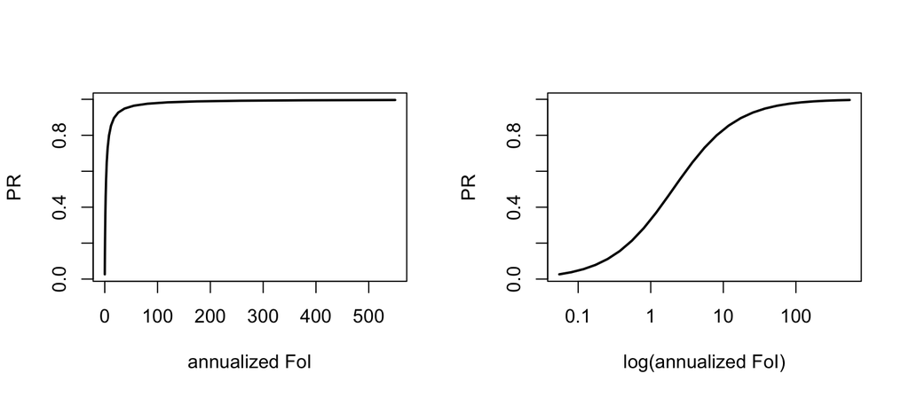

### Stable Orbits

While $h(t)$ could take on any values, we started by considering the case where it was constant. A sensible next step for analysis is to analyze models with a canonical signal such that $h(t+365) = h(t),$ then we do not get a stable state but a steady orbit. The following graph plots the stable orbits for two different canonical $h(t)$ patterns with two different seasonal patterns and average values.

**Figure 2** – Stable Orbits in Ross’s model.

- *top left* – The FoI patterns over a year; these are variants of trigonometric functions and power laws.
- *bottom left* – The PR patterns. Note that the higher the FoI the higher the PR.
- *top right* – The orbits. The mathematics were developed to understand the laws of planetary motion. By plotting the FoI *vs.* the PR, it might seem a bit more clear why we call these plots *orbits.*
- *bottom right* – the idea of a *steady state* can shed some light on the orbits. In this graph, we have plotted the *attractor* as a maroon line. It is defined as the steady state that would be reached if the conditions *at a point in time* were to hold forever. One way to understand the dynamics is through the study of the attractor – the orbit is being pulled towards the attractor *chasing it around* the phase plane:
  - When the attractor is above the orbit, the orbit is increasing;
  - when the attractor is below the orbit, the orbit is decreasing.
  - Points where the orbits and the attractor intersect are critical points for the orbits (*i.e.* maxima or minima). This means that the PR is still rising, even after exposure has peaked, or that the PR is still falling early in the transmission season, even after exposure rates have started to rise again.

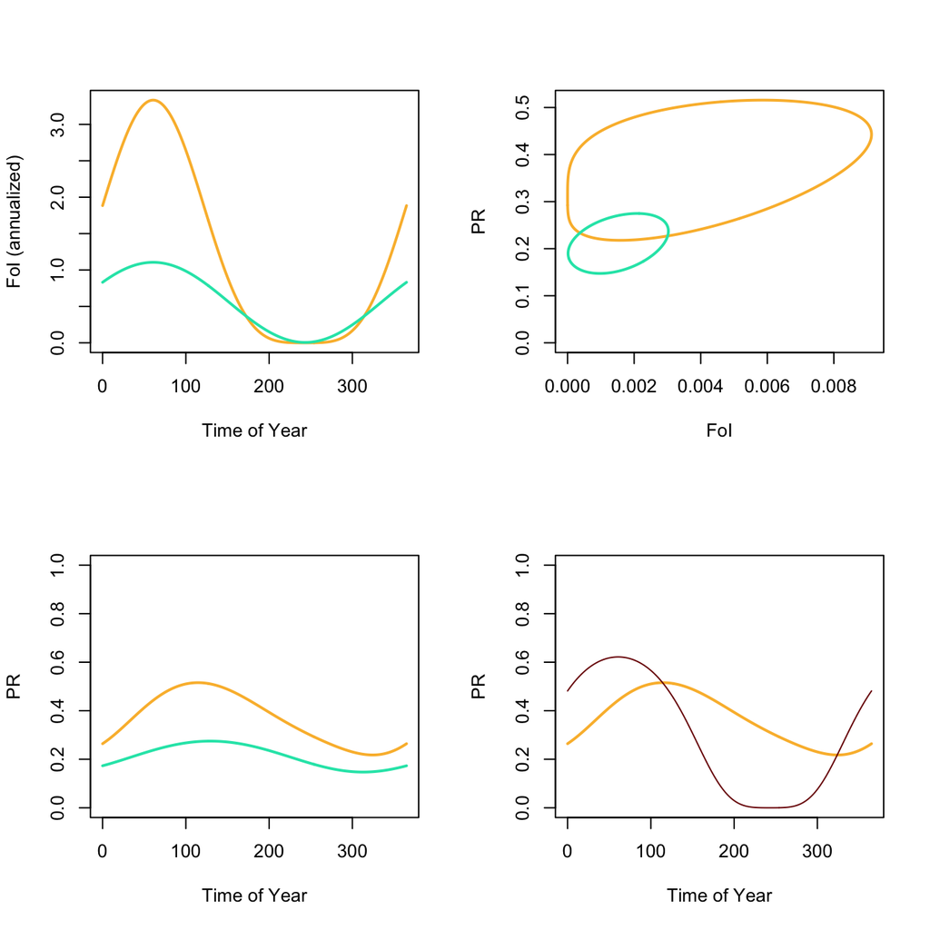

### Critique

Ross’s model for infection is as good a place as any to start, but if we want to study malaria or use models for analytics, there are several major issues that we must address if we want to use it. Does it get get the scaling relationships right? Close enough to be useful? Each one of the sections that follow addresses the issues of realism.

## 2.

### $\oplus$

I was of three minds,  
Like a tree  
In which there are three blackbirds.

$\hat x = {\cal O}(x)$

### Background

A basic fact – ignored at our own peril – is that everything we know about the world is filtered through an observational process. Our life experience comes through our sensory organs. Despite this limitation, it is useful to imagine what the world would look like if we were omniscient.

The approach we take herein is to try and understand the truth that is generating our observations. One way to check ourselves is to pretend that we *are* not just omniscient, but capable of generating truth. We can develop models, simulate the true world and the observational process, and ask how close our study was to the truth. These *simulation studies* are one useful way of walking through an analysis where we know the answer.

In malaria, we understand malaria by measuring it. There are two big sets of metrics we need to consider: research metrics, and health systems metrics [25–27].

### Research Metrics

- The *Pf*PR, the prevalence of malaria in cross-sectional blood surveys, is most commonly used research metric. Age-specific patterns in *Pf*PR have been described for 27 datasets that reported *Pf*PR highly stratified by age [28]. A common pattern in those datasets had several features: a rapid increase in prevalence with age, reaching a plateau sometime after age 2 and before age 5; a decline in prevalence starting around age 10 that continues through adolescence and into adulthood, such that the prevalence in adults is roughly 1/3 of the plateau.
- The annual *Pf*EIR and the seasonal pattern of the daily FoI.
- The force of infection (FoI).
- Serology.

### Health Systems Metrics

- Case Counts
- TPR

### Models & Data

### **State Space Modeling**

To be useful in policy, we want to use simulation models to help us understand malaria transmission dynamics and control well enough to support decisions. Instead of regarding the models as abstract objects, we want to model malaria in some particular place in the recent past leading up to the present, and in the immediate future. We must think about the models as approximations of a *particular* messy and complex reality. We need an inferential framework. The reality we must confront is our inability to observe reality directly. Instead, we know about reality through an observational process that generates data. We learn about reality through the analysis of patterns in the data.

We regard these mechanistic models as approximations. In the state space modeling framework that we have adopted, the state variables, parameters, and terms in our mechanistic models are also not directly observable, so we call them *latent states.* We must be very specific about how these variables get translated into observable states through a model of the observational process. These observable states are what we are comparing to the malaria metrics (*i.e.*, to data).

[figure not shown]

### Skill Sets

As we compare mechanistic models to each other, and as we challenge models with data, we note some important differences or limitations in how much various models can do for us. Each model represents the *state* of a system to varying degrees of detail and abstraction. For example, models of malaria epidemiology are generically defined by a set of state variables, represented by $\cal X$, with dynamics,

$$d {\cal X}/dt = F_{\cal X} ({\cal
X}).$$

If we want to fit models to data, we embed our mechanistic model in a state space modeling framework by defining an observational process model that translates the states of the mechanistic model onto a set of metrics through an observational process model, $O$, where:

$$O({\cal X}, \ldots) \rightarrow \hat
X.$$

We define the **scope** of a state space model as the full set of defined observable quantities, a set $\left\{\hat X_i\right\}.$

If we want to discuss mechanistic models, we can simply discuss the state variables or *states* of the system, but in a state space modeling framework, we need to be more careful about using the term “states”:

- In a state-space modeling framework, the variables in $\cal X$ are called *latent states.* Within the universe defined by the model, they are *putatively true,* but they can’t be observed directly and (with the exception of making ourselves omniscient when we conduct simulation studies) are thus only knowable through an observational process.
- The observational process model translates the latent states into *observable states*, $\left\{\hat X_i\right\}.$

As we compare the mechanistic models that we use within our fully-defined state-space models, we need to be able to discuss the capabilities of the mechanistic models in relation to the scope of a state-space model.

> The *skill set* of a mechanistic model is defined as the set of observable quantities that are naturally represented as functions of the latent states (*i.e.* the state variables of the mechanistic model) such that they can be computed without requiring extraneous information.

In some models, some observable quantities, or observable *states* can not be computed naturally from the latent variables without adding substantial additional information. If we have defined a minimal *scope* for our study, it might be possible to augment the observational process model with other information to define a useful function $O({\cal X}, \ldots).$

In the following, we define the skill set of various models used in malaria epidemiology, dynamics, and control, and we illustrate through examples how models with limited skill sets have been extended their scope.

## 3.

### $\oplus$

The blackbird whirled in the autumn winds.  
It was a small part of the pantomime.

$\frac{dm}{dt} = h-rm$

### **Superinfection**

- `Queueing` describes a queuing model for the MoI called $M/M/\infty$
- `Hybrid` describes a queuing model for the MoI

### Queueing

The queuing model of infection subdivides a population by MoI and tracks the transitions among states:

$$\begin{array}{c}
\begin{array}{ccccccccc}
M_0 & {h\atop \longrightarrow} \atop {\longleftarrow \atop r} &
M_1 & {h\atop \longrightarrow} \atop {\longleftarrow \atop {2r}}
& M_2 & {h \atop \longrightarrow} \atop {\longleftarrow \atop
{3r}} & M_3 & {h \atop \longrightarrow} \atop {\longleftarrow
\atop {4r}}& \ldots
\end{array}
\\
\\
\begin{array}{rl}
dM_0/dt &= -h M_0 + r M_1 \\
d M_i /dt &= -(h+r) M_i + h M_{i-1} + r(i+1) M_{i+1} \\
\end{array}
\end{array}$$

A diagram of the queuing model $M/M/\infty$ (top), and the master equations (bottom), in which $M_i$ denotes the proportion of the population with MoI $=i$. MoI increments by one if an infection occurs at rate $h$ and decrements by one if an infection clears at rate $ri$.

### Hybrid Models

$$dm = h-rm$$

## 4.

### $\oplus$

A man and a woman  
Are one.  
A man and a woman and a blackbird  
Are one.

$\begin{array}{rl} \frac{dX}{dt} &= h (H-X)-rX \\ \frac{dw}{dt} &= h - \mu w \\ \\ \hline \\ \hat x &= {\cal O}(x, w) \end{array}$

### **Malaria Immunity**

- `Stages` – Stage-structured immunity (11)
- `Tracking` – Modeling immunity with tracking variables (12)
- `Cohorts` – Aging & Galerkin methods for cohort dynamics (13)

### Immune Stages

A mathematical model developed as part of the Garki Project [12] introduced the idea of modeling immunity in stages. A simpler version of the model was developed later by Klein, *et al.* [29]. Here, we present an even simpler version:

$$\begin{array}{rl}
\frac{dS_1}{da} &= B(t) + \theta S_2 - h S_1 + r_1 I_1 - \mu S_1\\
\frac{dI_1}{da} &= h S_1 - r_1 I_1 - \xi I_1 -\mu I_1 \\
\frac{dS_2}{da} &= h S_2 + r_2 I_2 - \theta S_2 - \mu S_2\\
\frac{dI_2}{da} &= \xi I_1 - h S_2 - r_2 I_2 - \mu I_2\\
\end{array}$$

### Immune Tracking

A model developed by Filipe introduced the idea of a *tracking variable,* a variable that tracks malaria exposure in a cohort as it ages [30]

$$\begin{array}{rl}
\dot P &= (h \rho(w) + \phi) (H-P) + \zeta(w) X - \sigma P \\
\dot U &= r X - (h \rho(w) + \phi) U \\
\dot X &= (1-\rho(w)) h U - (r + h \rho(w) + \zeta(w) + \phi) X \\
\dot w &= h - \xi w
\end{array}$$

## 5.

### $\oplus$

I do not know which to prefer,  
The beauty of inflections  
Or the beauty of innuendoes,  
The blackbird whistling  
Or just after.

$\begin{array}{rl} \frac{\textstyle{d X(a,t)}}{\textstyle{\partial a}} + \frac{\textstyle{d X(a,t)}}{\textstyle{\partial t}} &= h(a,t) (H-X)-(\mu +r)X\\ \frac{\textstyle{d H(a,t)}}{\textstyle{\partial a}} + \frac{\textstyle{H(a,t)}}{\textstyle{\partial t}} &= -\mu H\\ \\ \hline \\ X(0,t) &= 0 \\ H(0,t) &= B(t) \\ \end{array}$

### Demography

### Cohort Dynamics

In places where malaria transmission is *stable,* we can get a picture of malaria infection dynamics by looking at humans as they age. In effect we are using age as a surrogate for time. The dynamics look very similar (for Ross’s model):

$$\begin{array}{rl}
\frac{dX}{da} &= h (H-X)-(\mu +r)X\\
\frac{dH}{da} &= -\mu X\\
\end{array}$$

but we can definitively establish an initial condition; since on one is born infected with malaria, we set $X(0) = 0$. Now the dynamics describe how prevalence increases in cohorts as they age. The trick to aligning exposure is to establish the birth date of a cohort, $\tau$ and then age is $a = t-\tau.$ Using the same function we used for $h(t)$, we can look at infection dynamics in infants as they age.

In the following, the black line represents the PR for a population exposed at a constant rate. The colored lines represent cohorts born 90 days apart. A critical feature of these plots are that prevalence rises somewhat slowly to the stable state. Later, in 11, we’ll introduce methods that make it possible to do time and age at the same time.

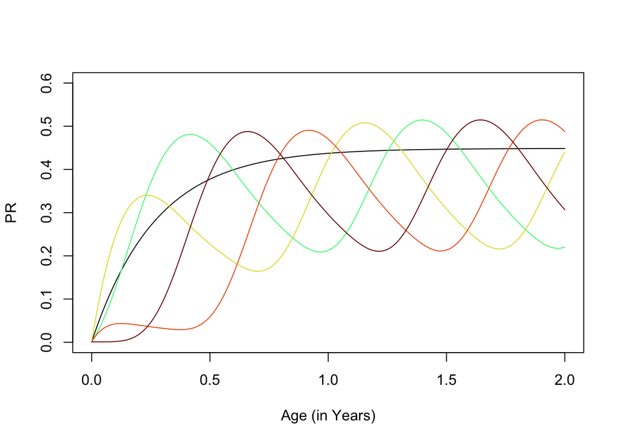

### Age & Time

$$\frac{\textstyle{d {\cal
X}}}{\textstyle{\partial a}} + \frac{\textstyle{d {\cal
X}}}{\textstyle{\partial t}} = F_{\cal X}(a, t | h(t))$$

## 6.

### $\oplus$

Icicles filled the long window  
With barbaric glass.  
The shadow of the blackbird  
Crossed it, to and fro.  
The mood Traced in the shadow  
An indecipherable cause.

$\begin{array}{rl} \frac{dX}{dt} &= h (1-\rho) (H-P) - (r + \zeta + \xi) X \\ \frac{dP}{dt} &= (\rho h + \xi)(H-P) + \zeta X - \eta P \\ \end{array}$

### **Treatment & Chemoprotection**

We want to examine cohort dynamics in a model where treatment can occur through one of three modes:

- $\rho$ is in response to an *acute-phase* infection
- $\xi$ is other treatment in infected individuals
- $\zeta$ is indiscriminate

$$\begin{array}{rl}
\frac{dX}{da} &= h (1-\rho) (H-P) - (r + \zeta + \xi) X \\
\frac{dP}{da} &= (\rho h + \xi)(H-P) + \zeta X - \eta P \\
\frac{dw}{da} &= h X
\end{array}$$

## 7.

### $\oplus$

O thin men of Haddam,  
Why do you imagine golden birds?  
Do you not see how the blackbird  
Walks around the feet  
Of the women about you?

$\begin{array}{rl} \dot L &= h U - h_\delta U_\delta \\ \dot X &= h_\delta U_\delta - r X\\ \\ \hline \\ H &= U + X + L \\ \end{array}$

### **Time Course / Phases of Infection**

### Liver Stages

This is effectively an $SEI_1I_2$ model, where $A = I_1$ and $X=I_2.$

$$\begin{array}{rl}
\dot L &= h U - \delta L\\
\dot A &= \delta E - \mu A\\
\dot X &= \mu A - r X\\
\end{array}$$

### Acute & Chronic Phases

Or we can do it with delays:

$$\begin{array}{rl}
\dot A &= h_\mu(H - P) - \Upsilon \; h_\delta
\left(H-P_\delta\right) \\
\end{array}$$

$$\frac{dX}{dt} = - \Theta \cdot X$$

### **Parasite Densities**

### Stage of Infection

Let $X$ denote the fraction of a population in each one of $n$ stages, $\mu_i$ the rate infections clear from a stage, $\theta_i$ the fraction that transition to a higher stage, and $\phi_i$ the fraction that transition to a lower stage. $\Theta$ is the transition matrix:

$$\Theta =
\left[\begin{array}{ccccc}
\mu_1 +\theta_1 & -\phi_2 & \ldots & . \\
-\theta_1 & \mu_2 + \phi_2+\theta_2 & \ldots & . \\
. & -\theta_2 & \ldots & . \\
\vdots & \vdots & \ddots & \vdots \\
. & .& \ldots & -\phi_n \\
. & . & \ldots & \mu_n + \phi_n \\
\end{array}\right]$$

We assume that superinfection occurs, and that all new infections are in stage $1$. We let $h$ denote the force of infection. The dynamics of a cohort of simple infections (, without superinfection) is described by:

$$\frac{dX}{dt} = - \Theta \cdot X$$

The matrix $\Theta$ describes a generalized phase-type distribution, and the matrix $\Theta^{-1}$ can be interpreted as a vector of residence times – the fraction of time a parasite infection in each stage would spend in every other stage, if there were no superinfection.

$$\begin{equation}
\frac{dX}{dt} = hz - \mbox{diag}(hz) \cdot l \cdot X - \Theta \cdot X
\end{equation}$$

The steady state is given by:

$$\begin{equation}
\bar X = \left( \mbox{diag}(hz) \cdot l + \Theta \right)^{-1} \cdot
hz
\end{equation}$$

$\left(\mbox{diag}(hz) \cdot l + \Theta\right) ^{-1}$, once again, describes a residence time from each stage to every other stage, but in this case, the residence times are affected by superinfection.

#### Non-Overwriting Superinfection Immune Formulation

As before, we denote the distribution over infection states at the start of an infection as $z$. We can model this as being primed by each infection independently and lasting for an average period of $\omega^{-1}$. The mean number of infections is

$$\begin{align*}
\frac{dm}{dt} &= h - rm
\end{align*}$$
The amount that $z$ is primed by each infection is proportional to $m$ with proportionality constant $\nu$, so that

$$\begin{align*}
\Sigma(m) &= \left[ \begin{array}{cccc}
\nu m & -\omega & ... & . \\
-\nu m & (\nu m + \omega) & -2\omega & . \\
. & . & . & . \\
0 & 0 & ... & 9\omega
\end{array} \right]
\end{align*}$$
Then we can write an equation for $z$ of the form

$$\begin{align*}
\frac{dz}{dt} &= - \Sigma(m) z
\end{align*}$$
with the initial condition $z_1 = 1$, $z_i = 0$ for all other $i$; that is, initially all infections begin in stage 1 and as immunity develops more infections start in a later stage.

The system of equations $X$ is then simplified to

$$\begin{align*}
\frac{dX}{dt} &= hz - \Theta X \\
\frac{dz}{dt} &= - \Sigma(m) z \\
\frac{dm}{dt} &= h - rm
\end{align*}$$
here we can renormalize $X$ to get the distribution of each infection across the stages.

### Age of Infection

## 8.

### $\oplus$

I know noble accents  
And lucid, inescapable rhythms;  
But I know, too,  
That the blackbird is involved  
In what I know.

$$\kappa = F_\kappa(x) = c x$$

### **Infectiousness**

## 9.

### $\oplus$

When the blackbird flew out of sight,  
It marked the edge  
Of one of many circles.

### **Disease**

### Anemia

## 10.

### $\oplus$

At the sight of blackbirds  
Flying in a green light,  
Even the bawds of euphony  
Would cry out sharply.

$h_i = F_h(E, \nu_i) = \frac{-\ln(1+b E \nu_i \phi)}{\phi}$

### **Heterogeneous Exposure**

### Environmental Heterogeneity

Environmental Heterogeneity

### Frailty

## 11.

### $\oplus$

He rode over Connecticut  
In a glass coach.  
Once, a fear pierced him,  
In that he mistook  
The shadow of his equipage  
For blackbirds.

### **Principled Stratification**

## 12.

### $\oplus$

The river is moving.  
The blackbird must be flying.

### **Complexity**

### SoI

#### $\oplus$

**Stage of Infection** models subdivide infections into $n$ stages.

- `Simple` - A SoI model for simple infections
- `Super` - A SoI model with superinfection

#### Simple

- $n$ is the number of stages
- $X_i$ is the density of the population with an infection in stage $i$
- $\nu_i$ is the rate an infection stages-up
- $r_i$ is the stage-specific clearance rate

$$\begin{array}{rl}
\dot U & = -h U + \sum r_i X_i \\
\dot X_1 & = h U - (r_1 + \nu_1) X_1 \\
\dot X_i & = \nu_{i-1} X_{i-1} - (h + r_i + \nu_i) X_i \\
\dot X_n & = \nu_{n-1} X_{n-1} - (h + r_n) X_n \\
\end{array}$$
Note that this does not allow for the SoI to decrease. Such a model is possible.

#### SoI + Superinfection

Here, we allow for over-writing superinfection:

- $X_i$ is the density with a *lowest* infected stage $i$
- $m_i$ is the mean multiplicity of infection for the $i^{th}$ stage
- Now $\nu_i$ and $r_i$ are functions of $m_i$

We develop a hybrid model to tracks the MoI in each stage:

$$\begin{array}{rl}
\dot m_1 & = h - (r_1 + \nu_1) m_1 \\
\dot m_i & = \nu_{i-1} m_{i-1} - (r_i + \nu_i) m_i \\
\dot m_n & = \nu_{n-1} m_{n-1} - (r_n + \nu_n) m_n \\
\end{array}$$

with dynamics:

$$\begin{array}{rl}
\dot U & = -h U + \sum r_i X_i \\
\dot X_1 & = h (H - X_1) - (r_1(m_1) + \nu_1(m_1)) X_1 \\
\dot X_i & = \nu_{i-1}(m_{i-1}) X_{i-1} - (h + r_i(m_i) +
\nu_i(m_i)) X_i \\
\dot X_n & = \nu_{n-1}(m_{n-1}) X_{n-1} - (h + r_n(m_n)) X_n \\
\end{array}$$

**Note** is this exposing a weirdness in the model? Advancing to the next stage *should* depend on the stage-specific MoI.

## 13.

### $\oplus$

It was evening all afternoon.  
It was snowing  
And it was going to snow.  
The blackbird sat  
In the cedar-limbs.

### **Relevant Detail**

### States

### Age *vs.* *Pf*PR

One of the dominant features of data describing malaria prevalence is a pattern with respect to age [28,31].

$$\begin{array}{rl}
\dot U & = -h U + \sum r_i X_i \\
\dot X_1 & = h (H - X_1) - (r_1 + \nu_1) X_1 \\
\dot X_i & = \nu_{i-1} X_{i-1} - (h + r_i + \nu_i) X_i \\
\dot X_n & = \nu_{n-1} X_{n-1} - (h + r_n) X_n \\
\dot w &= h - \xi w
\end{array}$$

To investigate, we assume parasite densities are a function of stage and immunity, so the probability of detection is:

$$x = F_x(c_i X_i, w)$$

### PDG model

We add an acute phase. We assume that the stages track acute stage infections, but a person can also carry an acute-stage infection. We introduce a chemo-protected state, $P$, after treatment

- $A$ is the acute phase: any susceptible individual can be in both states;
- Let $\mu$ denote the duration of the latent period. We let $h_\mu = h(t-\mu)$ denote the FoI at time $t-\mu$ time units ago; the acute phase
- Let $\rho(w) A$ denote the treatment rate in response to a primary fever.
- Let $\zeta_i(w)$ denote the treatment rate in response to a secondary fever, by stage.
- Let $\xi$ denote the indiscriminate treatment rate.

$$\begin{array}{rl}
\dot P &= \left(\rho\left(w\right) A + \xi \right) \left(H-P\right)
+ \sum \zeta_i(w) X_i - \sigma P \\
\dot U & = \sigma P - \left(\rho\left(w\right) A + \xi \right) U -
h_\delta U + \sum_i r_i X_i \\
\dot X_1 & = \Upsilon \; h_\delta \left(H -X_1\right) - \left(r_1 +
\nu_1 + \zeta_1 (w) + \rho\left(w\right)A + \xi \right) X_1 \\
\dot X_i & = \nu_{i-1} X_{i-1} - \left(\Upsilon \; h_\delta + r_i +
\nu_i + \zeta_i (w) + \rho\left(w\right)A + \xi \right) X_i \\
\dot X_n & = \nu_{n-1} X_{n-1} - \left(\Upsilon \; h_\delta + r_n +
\zeta_n (w) + \rho\left(w\right)A + \xi \right) X_i \\
\dot A &= h_\mu(H - P_\mu) - \Upsilon \; h_\delta
\left(H-P_\delta\right) \\
\dot w &= h - \xi w
\end{array}$$

Where we use Sean’s trick to compute treatment during the acute phase, $\Upsilon$

$$\dot \Upsilon = -\left[(\dot P + \sigma P)_\mu - (\dot P + \sigma
P)_\delta \right]\Upsilon$$

and detection by light microscopy:

$$c_A A + (1-c_A A) \sum_i c_i(w) X(w)$$

and detection by RDT?

Disease is subdivided into mild, moderate, and severe. Also, we need to make some kind of decision about how to handle *anemia.*

- **Severe** We assume that *most* severe disease is associated with a primary fever
  $$\propto \rho(w)A$$
- **Moderate** We assume that *most* moderate disease is associated with a primary fever *or* an early stage infection
  $$\propto \rho(w)A + \rho_1(w)
  X_1$$
- **Mild** We assume that *some* mild disease is the result of a primary fever, but *most* mild disease arises from secondary fever
  $$\propto \rho(w)A +
  \sum_i \zeta_i(w) X_i$$

## $\dagger$

**Contributors**

- David L. Smith

**References**

1.

Smith DL, Battle KE, Hay SI, Barker CM, Scott TW, McKenzie FE. Ross, Macdonald, and a theory for the dynamics and control of mosquito-transmitted pathogens. PLoS Pathog. 2012;8: e1002588. doi:10.1371/journal.ppat.1002588

2.

Reiner RC Jr, Perkins TA, Barker CM, Niu T, Chaves LF, Ellis AM, et al. A systematic review of mathematical models of mosquito-borne pathogen transmission: 1970-2010. J R Soc Interface. 2013;10: 20120921.

3.

Smith NR, Trauer JM, Gambhir M, Richards JS, Maude RJ, Keith JM, et al. Agent-based models of malaria transmission: A systematic review. Malar J. 2018;17: 299. doi:10.1186/s12936-018-2442-y

4.

Ross R. The logical basis of the sanitary policy of mosquito reduction. Science. 1905;22: 689–699. doi:10.1126/science.22.570.689

5.

Ross R. The prevention of malaria in British possessions, Egypt, and parts of America. The Lancet. 1907; 879–887.

6.

Ross R. Report on the Prevention of Malaria in Mauritius. London: Waterlow; 1908.

7.

Ross R. The Prevention of Malaria. 2nd ed. London: John Murray; 1911.

8.

Macdonald G. The analysis of malaria parasite rates in infants. Tropical diseases bulletin. 1950;47: 915–938.

9.

Malaria WEC on. Expert Committee on Malaria, Sixth Report. Athens: Geneva: Palais des Nations.; 1957. Report No.: 123. Available: https://www.cabdirect.org/cabdirect/abstract/19582900403

10.

Macdonald G, Goeckel GW. The malaria parasite rate and interruption of transmission. Bull World Health Organ. 1964;31: 365–377. Available: https://www.ncbi.nlm.nih.gov/pubmed/14267746

11.

Nájera JA. A critical review of the field application of a mathematical model of malaria eradication. Bull World Health Organ. 1974;50: 449–457. Available: http://www.ncbi.nlm.nih.gov/entrez/query.fcgi?cmd=Retrieve&db=PubMed&dopt=Citation&list_uids=4156197

12.

Dietz K, Molineaux L, Thomas A. A malaria model tested in the African savannah. Bull Wld Hlth Org. 1974;50: 347–357. Available: http://www.ncbi.nlm.nih.gov/entrez/query.fcgi?cmd=Retrieve&db=PubMed&dopt=Citation&list_uids=4613512

13.

Macdonald G. The analysis of infection rates in diseases in which superinfection occurs. Trop Dis Bull. 1950;47: 907–915. Available: https://www.ncbi.nlm.nih.gov/pubmed/14798656

14.

Fine PEM. Superinfection - a problem in formulating a problem. Tropical Diseases Bulletin. 1975;75: 475–488.

15.

Dutertre J. Etude d’un modèle épidémiologique appliqué au paludisme. Ann Soc Belg Med Trop. 1976;56: 127–141. Available: http://lib.itg.be/open/ASBMT/1976/1976asbm0127.pdf

16.

Ross R. On some peculiar pigmented cells found in two mosquitos fed on malarial blood. British medical journal. 1897;2: 1786–1788. Available: http://www.bmj.com/content/2/1929/1786.full.pdf

17.

Ross R. Extermination of Malaria. Ind Med Gaz. 1899;34: 231–232. Available: https://www.ncbi.nlm.nih.gov/pmc/articles/PMC5145409/

18.

Lotka AJ. Contribution to the Analysis of Malaria Epidemiology. I. General Part. American Journal of Epidemiology. 1923;3: 1–36. doi:10.1093/oxfordjournals.aje.a118963

19.

Lotka AJ. Contribution to the Analysis of Malaria Epidemiology. II. General Part (continued). Comparison of Two Formulae given by Sir Ronald Ross. American Journal of Epidemiology. 1923;3: 38–54. doi:10.1093/oxfordjournals.aje.a118965

20.

Lotka AJ. Contribution to the Analysis of Malaria Epidemiology. III. Numerical Part. American Journal of Epidemiology. 1923;3: 55–95. doi:10.1093/oxfordjournals.aje.a118966

21.

Lotka AJ. Contribution to the Analysis of Malaria Epidemiology. V. Summary. American Journal of Epidemiology. 1923;3: 113–121. doi:10.1093/oxfordjournals.aje.a118964

22.

Ross R. Some quantitative studies in epidemiology. Nature. 1911;87: 466–467.

23.

Lotka AJ. Quantitative Studies in Epidemiology. Nature. 1912;88: 497–498. doi:10.1038/088497b0

24.

Pull JH, Grab B. A simple epidemiological model for evaluating the malaria inoculation rate and the risk of infection in infants. Bull World Health Organ. 1974;51: 507–516. Available: http://www.ncbi.nlm.nih.gov/entrez/query.fcgi?cmd=Retrieve&db=PubMed&dopt=Citation&list_uids=4549501

25.

Hay SI, Smith DL, Snow RW. Measuring malaria endemicity from intense to interrupted transmission. Lancet Infect Dis. 2008;8: 369–378. doi:10.1016/S1473-3099(08)70069-0

26.

Smith DL, Smith TA, Hay SI. Measuring malaria for elimination. In: Feachem RGA, Phillips AA, Targett GAT, editors. Shrinking the Malaria Map. San Francisco, CA: University of California, San Francisco; 2009. pp. 108–126. Available: http://www.worldcat.org/title/shrinking-the-malaria-map-a-prospectus-on-malaria-elimination/oclc/421361248

27.

Tusting LS, Bousema T, Smith DL, Drakeley C. Measuring changes in *Plasmodium* *Falciparum* transmission: Precision, accuracy and costs of metrics. Adv Parasitol. 2014;84: 151–208. doi:10.1016/B978-0-12-800099-1.00003-X

28.

Smith DL, Guerra CA, Snow RW, Hay SI. Standardizing estimates of the *Plasmodium* *Falciparum* parasite rate. Malar J. 2007;6: 131. doi:10.1186/1475-2875-6-131

29.

Klein EY, Smith DL, Boni MF, Laxminarayan R. Clinically immune hosts as a refuge for drug-sensitive malaria parasites. Malar J. 2008;7: 67. doi:10.1186/1475-2875-7-67

30.

Filipe JAN, Riley EM, Drakeley CJ, Sutherland CJ, Ghani AC. Determination of the Processes Driving the Acquisition of Immunity to Malaria Using a Mathematical Transmission Model. PLOS Computational Biology. 2007;3: e255. doi:10.1371/journal.pcbi.0030255

31.

Mappin B, Cameron E, Dalrymple U, Weiss DJ, Bisanzio D, Bhatt S, et al. Standardizing *Plasmodium* *Falciparum* infection prevalence measured via microscopy versus rapid diagnostic test. Malar J. 2015;14: 460. doi:10.1186/s12936-015-0984-9